# hw1.Rmd

Kobe Pranivong; GitHub: illuminobe

1/15/2020

1. Create a folder named `ds202_hw1`, and create an RMarkDown file `hw1.Rmd` under this folder to include your solutions. The file and folder names are *case-sensitive*, which means `hw1.Rmd` and `HW1.rmd` are different. *It is crucial to follow the exact folder structure and file names*, so that your homework can be reproduced and graded by an automated script.
2. Write your name and Github username in the YAML of your homework `Rmd` file.
3. Write a paragraph (<100 words) describing a job that you think is related to data science. Write your paragraph in R Markdown in a nice format to read. Include at least
   1. a link
   2. an image
   3. an italized and a bolded word.

   I think a job that is related to data science is working as a **Statistician** because *statistics* is one of the most fundamental parts of data science. Statistical methods allows us to have deeper insight into data and helps us analyze and quantify any uncertainty. Josh Wills [tweeted](https://twitter.com/josh_wills/status/198093512149958656?s=20), “Data Scientist (n.): Person who is better at statistics than any software engineer and better at software engineering than any statistician.”, which improves my opinion that a Statistician is a job related to data science.

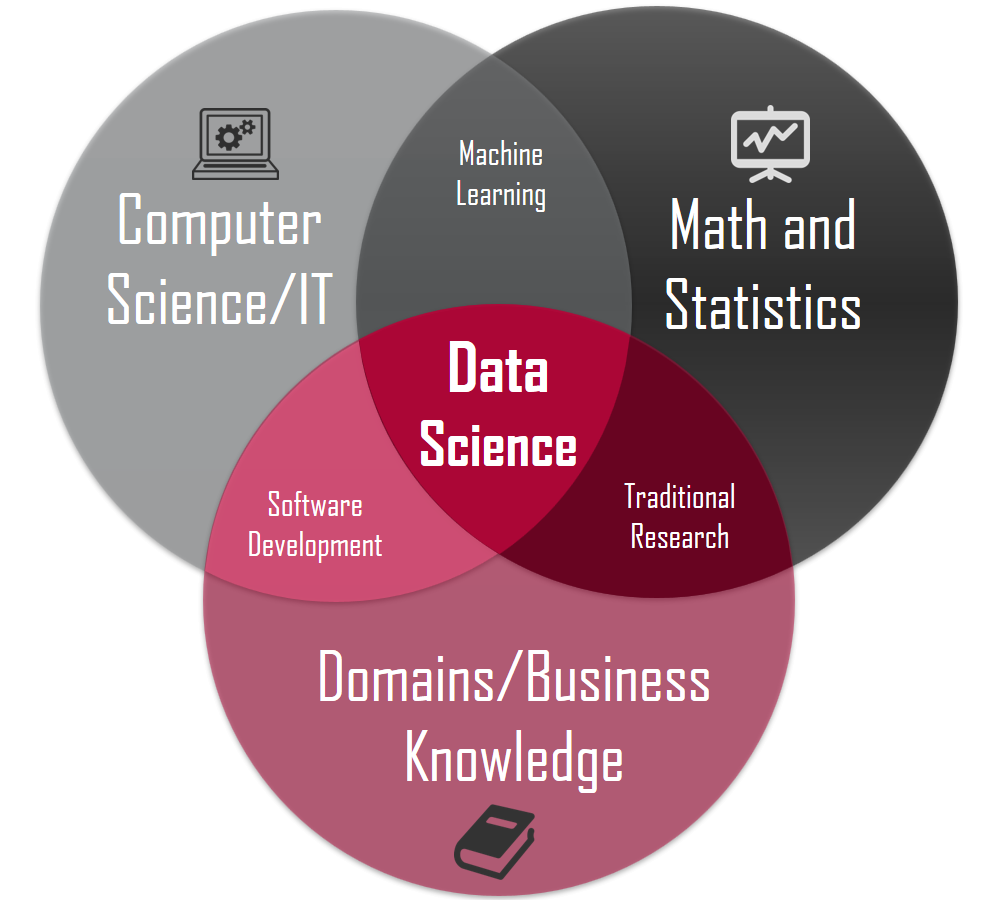

4. To make sure your R and Rstudio installation is correct, find the version of R by entering `version` into the R console. Put this command into a R code trunk in your `Rmd` file to automatically include the R version in your report.

   ```r
   version
   ```

   ```
   ##                _
   ## platform       x86_64-w64-mingw32
   ## arch           x86_64
   ## os             mingw32
   ## system         x86_64, mingw32
   ## status
   ## major          3
   ## minor          6.2
   ## year           2019
   ## month          12
   ## day            12
   ## svn rev        77560
   ## language       R
   ## version.string R version 3.6.2 (2019-12-12)
   ## nickname       Dark and Stormy Night
   ```

5. Install git.
   - If you are on Windows operating system:
     1. Install [Git for Windows](https://gitforwindows.org/). In particular, we will need to use the Git Bash (not the Git GUI).
     2. After installation, set up Rstudio to use Git bash as the shell for the Terminal: Open RStudio, click Tools–Global Options–Terminal; under **Shells**, select Git Bash; click OK.
     3. In the main menu of RStudio: click Tools–Terminal–New Terminal. If you have a `$` before your prompt, then you should not need to do anything.
   - If you are on Linux or macOS, Git has probably been correctly configured by default, so nothing needs to be installed. Just click the Terminal tab (above the R Console).
6. What is the version of your Git? To find out, go to the Terminal tab in RStudio (right to the Console tab), and type in the following command. If it works, this shows that the setup of your terminal and Git is correct. Then explore the bash command line and Git.

   My version of git is 2.25.0.windows.1.

   ```
   git --version
   ```

7. Configure Git by modifying and entering the following commands into the terminal

   ```
   git config user.name "Kobe Pranivong"
   git config user.email "kobae@iastate.edu"
   ```

8. Register a [GitHub](https://www.github.com) account. What is your username? Now Knit the finished Homework 1 one last time, and you are done! The actual submission (push to a GitHub repository) will take place in Lab 1.